# Global settings

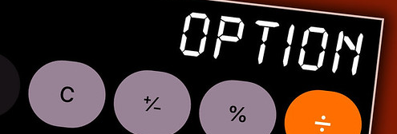

*Option* by Mike Lawrence is licensed under [CC BY 2.0 DEED](https://creativecommons.org/licenses/by/2.0/)

Global options are provided for arguments that users are likely prefer to set once in a document instead of repeating in every function call. For example, some users prefer a comma decimal marker (“,”) throughout a document.

Globally-set arguments can be overridden locally by assigning them in a function call.

## `formatdown_options()`

Set, examine, or reset several global options which affect the way in which a formatted object is rendered in an R markdown document. The options and their default settings are

```r
formatdown_options(delim = "$",
                   size = NULL,
                   decimal_mark = ".",
                   big_mark = "",
                   big_interval = 3,
                   small_mark = "",
                   small_interval = 5,
                   whitespace = "\\\\>",
                   multiply_mark = "\\times",
                   Z = FALSE,
                   reset = FALSE)
```

To reset all formatdown arguments to their default values:

```r
    formatdown_options(reset = TRUE)
```

*Usage.* For example, get two of the current settings.

```r
formatdown_options("size", "decimal_mark")
```

```
#> $size
#> NULL
#>
#> $decimal_mark
#> [1] "."
```

Assign new settings; examine result.

```r
# Set
formatdown_options(size = "large", decimal_mark = ",")

# Examine result
formatdown_options("size", "decimal_mark")
```

```
#> $size
#> [1] "large"
#>
#> $decimal_mark
#> [1] ","
```

Reset to default values; examine result.

```r
# Set to defaults
formatdown_options(reset = TRUE)

# Examine result
formatdown_options("size", "decimal_mark")
```

```
#> $size
#> NULL
#>
#> $decimal_mark
#> [1] "."
```

## Delimiters

Delimiters are characters that surround a formatted expression such that R Markdown renders it as an inline math expression.

Sometimes the default `$ ... $` delimiters fail to render correctly. I encountered this once using `kableExtra::kbl()` in a `.qmd` document. The solution, suggested by (*TeX and LaTeX math delimiters*, 2024), is to use the delimiter pair `\( ... \)`, hence the built-in alternate, `delim = "\\("`.

Left and right custom delimiters can be assigned in a vector, e.g., `c("\\[", "\\]")`.

*Examples.* Note that using `format_text()` introduces additional markup inside the delimiters. Details are described in the Format text article.

```r
x <- 101300
txt <- "Hello world!"

# 1. Numeric input, default delimiters
format_dcml(x)
```

```
#> [1] "$101300$"
```

```r
# 2. Numeric input, alternate delimiters
format_dcml(x, delim = "\\(")
```

```
#> [1] "\\(101300\\)"
```

```r
# 3. Character input, default delimiters
format_text(txt)
```

```
#> [1] "$\\mathrm{Hello\\ world!}$"
```

```r
# 4. Character input, alternate delimiters
format_text(txt, delim = "\\(")
```

```
#> [1] "\\(\\mathrm{Hello\\ world!}\\)"
```

Examples 1–4 (in inline code chunks) render as,

1. $\small 101300$
2. $\small 101300$
3. $\small \mathrm{Hello\ world!}$
4. $\small \mathrm{Hello\ world!}$

## Font size

Font size is set using LaTeX-style macros inside the math-delimited expression. For example, with `size = "small"` (or `size = "\\small"`), the formatdown markup of the Avogadro constant would be

```
    "$\\small 6.0221 \\times 10^{23}$",
```

where the extra backslashes are necessary to escape the backslashes in `\small` and `\times`. If `size = NULL` (default), no size command is added and the font size is equivalent to `"normalsize"`.

*Examples.*

```r
# 5. Numeric input
format_dcml(x, size = "scriptsize")
```

```
#> [1] "$\\scriptsize 101300$"
```

```r
# 6. Numeric input
format_dcml(x, size = "small")
```

```
#> [1] "$\\small 101300$"
```

```r
# 7. Power-of-ten number using LaTeX-style size markup
format_sci(6.0221e+23, size = "\\small")
```

```
#> [1] "$\\small 6.022 \\times 10^{23}$"
```

```r
# 8. Character input, default size
format_text(txt)
```

```
#> [1] "$\\mathrm{Hello\\ world!}$"
```

```r
# 9. Character input
format_text(txt, size = "large")
```

```
#> [1] "$\\large \\mathrm{Hello\\ world!}$"
```

Examples 5–9 render as,

5. $\scriptsize 101300$
6. $\small 101300$
7. $\small 6.022 \times 10^{23}$
8. $\mathrm{Hello\ world!}$
9. $\large \mathrm{Hello\ world!}$

*Available sizes*

Comparing decimal notation, scientific notation, and text in possible font sizes (formatdown does not support the sizes: tiny, footnotesize, Large, LARGE, and Huge).

| scriptsize | small | normalsize | large | huge |
| --- | --- | --- | --- | --- |
| $\scriptsize 3.1416$ | $\small 3.1416$ | $\normalsize 3.1416$ | $\large 3.1416$ | $\huge 3.1416$ |
| $\scriptsize 5 \times 10^{3}$ | $\small 5 \times 10^{3}$ | $\normalsize 5 \times 10^{3}$ | $\large 5 \times 10^{3}$ | $\huge 5 \times 10^{3}$ |
| $\scriptsize \mathrm{The\ cat}$ | $\small \mathrm{The\ cat}$ | $\normalsize \mathrm{The\ cat}$ | $\large \mathrm{The\ cat}$ | $\huge \mathrm{The\ cat}$ |

## Decimal separator

For a number written in decimal form, the decimal mark separates the integer part from the fractional part.

- A period or dot (“.”) is the conventional decimal mark in the US, Australia, Canada (English-speaking), Mexico, the UK, much of eastern Asia, and other regions.
- A comma (“,”) is the conventional decimal mark in Brazil, Canada (French-speaking), much of Europe and Latin America, Russia, and other regions.

The decimal mark in formatdown may be reset locally in a function call or globally using `formatdown_options()`; it is not affected by the base R option `OutDec`.

*Examples.*

```r
# 10. Decimal markup
x <- pi
format_dcml(x, 5, decimal_mark = ",")
```

```
#> [1] "$3,1416$"
```

```r
# 11. Power-of-ten markup
y <- 1.602176634e-19
format_sci(y, 5, decimal_mark = ",")
```

```
#> [1] "$1,6022 \\times 10^{-19}$"
```

Examples 10 and 11 render as,

10. $\small 3,1416$
11. $\small 1,6022 \times 10^{-19}$

## Separating digits

The NIST recommends we use a thin space to separate more than 4 digits to the left or to the right of a decimal marker (Thompson & Taylor, 2022, p. 10.5.3):

> … digits should be separated into groups of three, counting from the decimal marker towards the left and right, by the use of a thin, fixed space. However, this practice is not usually followed for numbers having only four digits on either side of the decimal marker except when uniformity in a table is desired.

Both `big_mark` and `small_mark` add the horizontal-space characters inside the math delimiters; `big_mark` to the integer portion and `small_mark` to the fractional portion. The possible values are empty `""` (default), `"thin"`, or the thin-space macro itself `\\\\,`.

The interval arguments `big_interval` and `small_interval` set the number of digits separated by thin spaces when `big_mark` or `small_mark` are not empty. However, formatdown does not encode the exemption for 4-digit groups mentioned in the NIST quote above.

*Examples.*

```r
w <- 1013
x <- 101300
y <- 0.002456
z <- x + y

# 12. 4-digit number, no space
format_dcml(w)
```

```
#> [1] "$1013$"
```

```r
# 13. 4-digit number, with space
format_dcml(w, big_mark = "thin")
```

```
#> [1] "$1\\,013$"
```

```r
# 14. Group digits to the left of the decimal
format_dcml(x, big_mark = "thin")
```

```
#> [1] "$101\\,300$"
```

```r
# 15. Group digits to the right of the decimal
format_dcml(y, small_mark = "\\\\,")
```

```
#> [1] "$0.00245\\,6$"
```

```r
# 16. Change the small interval
format_dcml(y, small_mark = "\\\\,", small_interval = 3)
```

```
#> [1] "$0.002\\,456$"
```

```r
# 17. Group digits to the left and right of the decimal
format_dcml(z, 12, big_mark = "thin", small_mark = "thin")
```

```
#> [1] "$101\\,300.00245\\,6$"
```

Examples 12–17 render as,

12. $\small 1013$
13. $\small 1\,013$
14. $\small 101\,300$
15. $\small 0.00245\,6$
16. $\small 0.002\,456$
17. $\small 101\,300.00245\,6$

## Preserving text spaces

The horizontal-space macro is used to preserve spaces in text formatted with `format_text()` as well as spaces within physical-unit strings with `format_numbers()`. Without it, an inline math markup such as

```
    $\mathrm{This Is Math Text.}$
```

is rendered in an R markdown document as

$\qquad$ $\small\mathrm{This Is Math Text.}$

To preserve such spaces, formatdown substitutes the character string `\>` for each space, producing output like the following, where backslashes have been escaped,

```
    "$\\mathrm{This\\>Is\\>Math\\>Text.}$"
```

rendered as,

$\qquad$ $\small\mathrm{This\>Is\>Math\>Text.}$

Because the backslashes must be escaped, the formatdown output is $\small\mathtt{\verb|"\\>"|}$, but the the argument value set by the user is `whitespace =` $\small\mathtt{\verb|"\\\\>"|}$. One may also use $\mathtt{\small\verb|"\\\\:"|}$ or $\mathtt{\small\verb|"\\\\ "|}$.

*Examples.*

```r
# 18. Character input, default space "\>"
format_text(txt, whitespace = "\\\\>")
```

```
#> [1] "$\\mathrm{Hello\\>world!}$"
```

```r
# 19. Character input, alternate space "\:"
format_text(txt, whitespace = "\\\\:")
```

```
#> [1] "$\\mathrm{Hello\\:world!}$"
```

```r
# 20. Character input, alternate space "\ "
format_text(txt, whitespace = "\\\\ ")
```

```
#> [1] "$\\mathrm{Hello\\ world!}$"
```

## Multiplication symbol

The default symbol used in power of ten notation is “$\small\times$”, as in $\small 3.14 \times 10^{-3}$. An alternate—often used when the decimal marker is a comma—is the centered dot, e.g., $\small 3,14 \cdot 10^{-3}$.

The symbol is set using the `multiply_mark` argument. The default setting is `"\\times"`; the alternate, centered-dot setting, is `"\\cdot"`.

*Examples.*

```r
# 21. Alternate multiplication symbol
y <- 1.602176634e-19
format_sci(y, 5, decimal_mark = ",", multiply_mark = "\\cdot")
```

```
#> [1] "$1,6022 \\cdot 10^{-19}$"
```

Example 21 renders as:

21. $\small 1,6022 \cdot 10^{-19}$

## Applications

*Example 22.*

In this example, we format different columns of a data frame using `decimal_mark`, `big_mark` and `small_mark`.

```r
# Set options
formatdown_options(decimal_mark = ",", big_mark = "thin", small_mark = "thin")

# Use water data included with formatdown
DT <- copy(water)[1:6]

# Examine the data frame
DT[]
```

```
#>      temp   dens   sp_wt       visc bulk_mod
#>     <num>  <num>   <num>      <num>    <num>
#> 1: 273.15 999.87 9808.70 0.00173360 2.02e+09
#> 2: 283.15 999.73 9807.33 0.00131050 2.10e+09
#> 3: 293.15 998.23 9792.67 0.00102120 2.18e+09
#> 4: 303.15 995.68 9767.60 0.00081743 2.25e+09
#> 5: 313.15 992.25 9733.95 0.00066988 2.28e+09
#> 6: 323.15 988.06 9692.90 0.00056046 2.29e+09
```

```r
# Routine decimal formatting
DT$temp <- format_dcml(DT$temp)
DT$dens <- format_dcml(DT$dens)

# Omit big_mark spacing for 4 digits
DT$sp_wt <- format_dcml(DT$sp_wt, 4, big_mark = "")

# Set significant digits (viscosity) to achieve a consistent string length
DT[visc >= 0.001, temp_visc := format_dcml(visc, 5)]
DT[visc < 0.001, temp_visc := format_dcml(visc, 4)]
DT[, visc := temp_visc]
DT[, temp_visc := NULL]

# Will appear with big_mark spacing, change from Pa to kPa
DT$bulk_mod_kPa <- format_dcml(DT$bulk_mod / 1000, 4)
DT$bulk_mod <- NULL

knitr::kable(DT, align = "r", caption = "Example 22.")
```

Example 22.

| temp | dens | sp_wt | visc | bulk_mod_kPa |
| --- | --- | --- | --- | --- |
| $\small 273,2$ | $\small 999,9$ | $\small 9809$ | $\small 0,00173\,36$ | $\small 2\,020\,000$ |
| $\small 283,2$ | $\small 999,7$ | $\small 9807$ | $\small 0,00131\,05$ | $\small 2\,100\,000$ |
| $\small 293,2$ | $\small 998,2$ | $\small 9793$ | $\small 0,00102\,12$ | $\small 2\,180\,000$ |
| $\small 303,2$ | $\small 995,7$ | $\small 9768$ | $\small 0,00081\,74$ | $\small 2\,250\,000$ |
| $\small 313,2$ | $\small 992,2$ | $\small 9734$ | $\small 0,00066\,99$ | $\small 2\,280\,000$ |
| $\small 323,2$ | $\small 988,1$ | $\small 9693$ | $\small 0,00056\,05$ | $\small 2\,290\,000$ |

```r
# Set package options to default values
formatdown_options(reset = TRUE)
```

*Example 23.*

Same table, but using power of ten formatting.

```r
# Use water data included with formatdown
DT <- copy(water)[1:6]

# Routine decimal formatting
cols <- c("temp", "dens", "sp_wt")
DT[, (cols) := lapply(.SD, function(x) format_dcml(x)), .SDcols = cols]

# Power of ten
DT$bulk_mod <- format_engr(DT$bulk_mod, 3)
DT$visc <- format_engr(DT$visc, 4, set_power = -3)

knitr::kable(DT, align = "r", caption = "Example 23.")
```

Example 23.

| temp | dens | sp_wt | visc | bulk_mod |
| --- | --- | --- | --- | --- |
| $\small 273.2$ | $\small 999.9$ | $\small 9809$ | $\small 1.734 \times 10^{-3}$ | $\small 2.02 \times 10^{9}$ |
| $\small 283.2$ | $\small 999.7$ | $\small 9807$ | $\small 1.310 \times 10^{-3}$ | $\small 2.10 \times 10^{9}$ |
| $\small 293.2$ | $\small 998.2$ | $\small 9793$ | $\small 1.021 \times 10^{-3}$ | $\small 2.18 \times 10^{9}$ |
| $\small 303.2$ | $\small 995.7$ | $\small 9768$ | $\small 0.8174 \times 10^{-3}$ | $\small 2.25 \times 10^{9}$ |
| $\small 313.2$ | $\small 992.2$ | $\small 9734$ | $\small 0.6699 \times 10^{-3}$ | $\small 2.28 \times 10^{9}$ |
| $\small 323.2$ | $\small 988.1$ | $\small 9693$ | $\small 0.5605 \times 10^{-3}$ | $\small 2.29 \times 10^{9}$ |

*Example 24.*

The `metals` data set includes columns of text and decimal and power-of-ten numbers.

```r
# Use water data included with formatdown
DT <- copy(metals)

# Examine the data frame
DT[]
```

```
#>            metal  dens  thrm_exp thrm_cond  elast_mod
#>           <char> <num>     <num>     <num>      <num>
#> 1: aluminum 6061  2700 2.430e-05    155.77 7.3084e+10
#> 2:        copper  8900 1.656e-05    392.88 1.1721e+11
#> 3:          lead 11340 5.274e-05     37.04 1.3790e+10
#> 4:      platinum 21450 9.000e-06     69.23 1.4686e+11
#> 5:    steel 1020  7850 1.134e-05     46.73 2.0684e+11
#> 6:      titanium  4850 9.360e-06      7.44 1.0204e+11
```

```r
# Text
DT$metal <- format_text(DT$metal)

# Decimal
cols <- c("dens", "thrm_cond")
DT[, (cols) := lapply(.SD, function(x) format_dcml(x)), .SDcols = cols]

# Power of ten
cols <- c("elast_mod", "thrm_exp")
DT[, (cols) := lapply(.SD, function(x) format_engr(x, 3)), .SDcols = cols]

knitr::kable(DT, align = "lrrrr", caption = "Example 24.")
```

Example 24.

| metal | dens | thrm_exp | thrm_cond | elast_mod |
| --- | --- | --- | --- | --- |
| $\small \mathrm{aluminum\ 6061}$ | $\small 2700$ | $\small 24.3 \times 10^{-6}$ | $\small 155.8$ | $\small 73.1 \times 10^{9}$ |
| $\small \mathrm{copper}$ | $\small 8900$ | $\small 16.6 \times 10^{-6}$ | $\small 392.9$ | $\small 117 \times 10^{9}$ |
| $\small \mathrm{lead}$ | $\small 11340$ | $\small 52.7 \times 10^{-6}$ | $\small 37.04$ | $\small 13.8 \times 10^{9}$ |
| $\small \mathrm{platinum}$ | $\small 21450$ | $\small 9.00 \times 10^{-6}$ | $\small 69.23$ | $\small 147 \times 10^{9}$ |
| $\small \mathrm{steel\ 1020}$ | $\small 7850$ | $\small 11.3 \times 10^{-6}$ | $\small 46.73$ | $\small 207 \times 10^{9}$ |
| $\small \mathrm{titanium}$ | $\small 4850$ | $\small 9.36 \times 10^{-6}$ | $\small 7.440$ | $\small 102 \times 10^{9}$ |

## References

*TeX and LaTeX math delimiters*. (2024). MathJax Consortium. https://docs.mathjax.org

Thompson, A., & Taylor, B. N. (2022). *NIST Guide to the SI, Chapter 10: More on Printing and Using Symbols and Numbers in Scientific and Technical Documents*. US National Institute of Standards and Technology. https://www.nist.gov/pml/special-publication-811/nist-guide-si-chapter-10-more-printing-and-using-symbols-and-numbers